# Introduction à la recherche reproductible

Mary Varoux LBBE

04/02/2020 - Séminaire étudiant mary.varoux@univ-lyon1.fr https://github.com/maryvaroux

# Open Science

## Contexte

[figure not shown]

## C’est quoi ?

Recherche reproductible

données + méta-données + matériel & méthodes

## Pourquoi on en parle ?

[figure not shown]

## Pourquoi on en parle ?

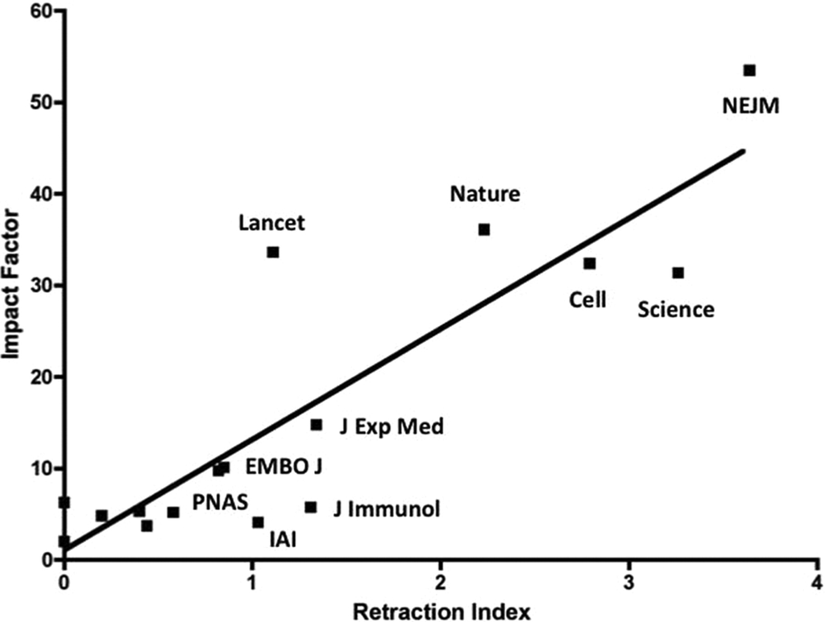

Ferric C. Fang, and Arturo Casadevall Infect. Immun. 2011;79:3855-3859

## Comment ?

Un article publié n’est que le sommet de l’iceberg que représente le processus de recherche.

- Data Management: sauvegarde des données brutes et intermédiaires, tout documenter pas, créer des données bien rangées pouvant être analysées
- Software: écrire, organiser et partager ses scripts et programmes utilisés dans l’analyse
- Tracking Changes: répertorier la façon dont les divers composants de votre projet changent dans le temps
- Collaboration: faciliter la compréhension des collaborateurs existants et nouveaux, et contribuer à un projet
- Project Organization: organiser les artefacts numériques d’un projet pour faciliter découverte et compréhension
- Manuscripts: écrire des manuscrits d’une manière qui laisse une piste d’audit et minimise la fusion manuelle des conflits

Wilson et al. 2016. Plos Comp Biol. https://arxiv.org/pdf/1609.00037.pdf

## Data Management

- Sauvegarder les données initiales en l’état (ne pas les modifier) et les mettre en lecture seule si possible
- Scripter l’acquisition des données au maximum (API), surtout si elles sont volumineuses (ne plus cliquer mais coder)
- Toute transformation sera scriptée = devient un résultat (80% du job)
- Générer les données que vous voudriez recevoir, pouvant être lues par tous (noms de colonnes explicites, en anglais, conventions, tidy)

## Software

Le code, les scripts

- Respecter au maximum les conventions de code de votre communauté, https://style.tidyverse.org/ (stylisation du code très détaillé)
- Peut importe la convention adoptée, rester constant !
- Chemins relatifs ! Toujours ! (Répertoire de projet R à privilégier)
- Pas d’espaces, d’accents dans les noms !
- Commenter/documenter les fonctions, les scripts (pensez à vous même dans 6 mois)

## Software

L’environnement logiciel.

- Les packages (version) : packrat (noms des fonction peuvent changer, sauvegarder le package dans la version utilisée)
- Bibliothèques système, de la version de R, de la version de l’OS ?!
- Docker (Rocker pour R), permet de créer une image de l’environnement de travail (OS, bibliothèques, R, packages) (https://colinfay.me/docker-r-reproducibility/ ; https://journal.r-project.org/archive/2017/RJ-2017-065/RJ-2017-065.pdf)

## Software

Le “workflow” (echaînement des scripts, des logiciels).

D’une manière générale automatiser au maximum

[figure not shown]

## Software

- il existe des outils pour ça (pseudo makefile en R, makefile shell, pipeline toolkits [Remake, Drake])
- Automatiser du script à la rédaction de l’article (Rmarkdown)
- Gère tout seul les dépendances entre scripts et données car cela est automatisé (le summum hein)

## Tracking Changes

Utiliser un logiciel de gestion de versions (Git)

## Collaboration

- Conventions de code (variable sans majuscule, sans espace..)
- Documentaiton de l’archive de recherche (Readme, License, code de contribution, avoir tout au même endroit c’est mieux : research compendium)
- Plateforme de collaboration en ligne (intègre Git !) : github, gitlab

## Project Organization

[figure not shown]